# Project 3: Death Penalty

Tim Hagemeister

29 September, 2019

# Introduction

In this lab, we’ll be making and interpreting contingency tables based on the death penalty dataset. I will demonstrate knowledge of basic probability concepts in the context of a real-world dataset.

```r
setnames(DeathP , old=c("Date",
                     "Name",
                     "Age",
                     "Sex",
                     "Race",
                     "Crime",
                     "Victim Count",
                     "Victim Sex",
                     "Victim Race",
                     "County",
                     "State",
                     "Region",
                     "Method",
                     "Juvenile",
                     "Volunteer",
                     "Federal",
                     "Foreign National"),
              new=c("Date",
                     "Name",
                     "Age",
                     "Sex",
                     "Race",
                     "Crime",
                     "VictimCount",
                     "VictimSex",
                     "VictimRace",
                     "County",
                     "State",
                     "Region",
                     "Method",
                     "Juvenile",
                     "Volunteer",
                     "Federal",
                     "ForeignNational"))
```

# Questions

**1) If an executed prisoner is randomly selected from the data, what’s the probability that they died by lethal injection?**

```r
DeathP %>%
  calc_cro(Method) %>%
  htmlTable(., css.cell = c("width: 130px",
      rep("width: 80px", ncol(.) - 1)))
```

|  | #Total |
| --- | --- |
| Method |  |
| Electrocution | 158 |
| Firing Squad | 3 |
| Gas Chamber | 11 |
| Hanging | 3 |
| Lethal Injection | 1267 |
| #Total cases | 1442 |

- The probability of random lethal injection would equal the number of lethal injections over the number of total cases= $1267/1442 = 0.879$

**2) If three executed prisoners are randomly selected from the data, what’s the probability that all three died by lethal injection? What assumption must you make in order to compute this probability? Is that a reasonable assumption?**

- in order to predict this probability, we have to multiply the probability of one lethal injection by the same probability Three times. Since the number of lethal injections is more than 5% of the total cases, it is probably best if we do not repalce the cases, therefore the equation is as follows:
  - P(lethal injection) x P(lethal injection) x P(lethal injection) =
  - (1267/1442) x (1266/1441) x (1265/1440) = **0.678**
  - during this probelm, we did not replace the subjects, this is because the value is greater than 5% of the total number of participants, thereofre we need to replace the value since 5% is the rule of thumb discussed in class.

**3) If an executed prisoner is randomly selected from the data, what’s the probability that they died by lethal injection given that they were executed in the south?**

```r
DeathP %>%
  calc_cro(Method, list(total(), Region)) %>%
  htmlTable(., css.cell = c("width: 130px",
      rep("width: 80px", ncol(.) - 1)))
```

|  | #Total | Midwest | Northeast | South | West |
| --- | --- | --- | --- | --- | --- |
| Method |  |  |  |  |  |
| Electrocution | 158 | 6 |  | 152 |  |
| Firing Squad | 3 |  |  |  | 3 |
| Gas Chamber | 11 |  |  | 6 | 5 |
| Hanging | 3 |  |  | 1 | 2 |
| Lethal Injection | 1267 | 172 | 4 | 1016 | 75 |
| #Total cases | 1442 | 178 | 4 | 1175 | 85 |

**4) If an executed prisoner is randomly selected from the data, what’s the probability that either they’re black or that they died in the south?**

```r
DeathP %>%
  calc_cro(Race, list(total(), Region)) %>%
  htmlTable(., css.cell = c("width: 130px",
      rep("width: 80px", ncol(.) - 1)))
```

|  | #Total | Midwest | Northeast | South | West |
| --- | --- | --- | --- | --- | --- |
| Race |  |  |  |  |  |
| Asian | 6 |  |  | 4 | 2 |
| Black | 495 | 63 |  | 426 | 6 |
| Latino | 120 |  |  | 114 | 6 |
| Native American | 16 | 1 |  | 11 | 4 |
| Other | 2 |  |  | 2 |  |
| White | 803 | 114 | 4 | 618 | 67 |
| #Total cases | 1442 | 178 | 4 | 1175 | 85 |

**5) If an executed prisoner is randomly selected from the data, what’s the probability that they’re both black and they died by electrocution?**

```r
DeathP %>%
  calc_cro(Method, list(total(), Race)) %>%
  htmlTable(., css.cell = c("width: 150px",
      rep("width: 80px", ncol(.) - 1)))
```

|  | #Total | Asian | Black | Latino | Native American | Other | White |
| --- | --- | --- | --- | --- | --- | --- | --- |
| Method |  |  |  |  |  |  |  |
| Electrocution | 158 |  | 70 | 1 | 1 |  | 86 |
| Firing Squad | 3 |  |  |  |  |  | 3 |
| Gas Chamber | 11 |  | 3 |  |  |  | 8 |
| Hanging | 3 |  |  |  |  |  | 3 |
| Lethal Injection | 1267 | 6 | 422 | 119 | 15 | 2 | 703 |
| #Total cases | 1442 | 6 | 495 | 120 | 16 | 2 | 803 |

- to calculate or probabilities we can just look at our chart that we created and observe how many individuals were black as well as died by electricution.
- p(Black or Died by electricution) = 70/1442 = **0.0485**

**6) Consider the events A and B, where:**

- **A = the event that a randomly selected executed prisoner is from the Midwest.**
- **B = the event that a randomly selected executed prisoner died by firing squad.**

```r
DeathP %>%
  calc_cro(Method, list(total(), Region)) %>%
  htmlTable(., css.cell = c("width: 150px",
      rep("width: 80px", ncol(.) - 1)))
```

|  | #Total | Midwest | Northeast | South | West |
| --- | --- | --- | --- | --- | --- |
| Method |  |  |  |  |  |
| Electrocution | 158 | 6 |  | 152 |  |
| Firing Squad | 3 |  |  |  | 3 |
| Gas Chamber | 11 |  |  | 6 | 5 |
| Hanging | 3 |  |  | 1 | 2 |
| Lethal Injection | 1267 | 172 | 4 | 1016 | 75 |
| #Total cases | 1442 | 178 | 4 | 1175 | 85 |

- **Are events A and B mutually exclusive? Why or why not?**
  - The events are mutually exclusive, this is because the two events, *Midwest* and *Death by firing squad* are imposible to happen at the same time.

**7) Consider the events A and B, where:**

- **A = the event that a randomly selected executed prisoner is from the West.**
- **B = the event that a randomly selected executed prisoner died by firing squad.**
  - **Using the definition of independence established in class, are events A and B independent? Why or why not? Is that the end of the story? Are we convinced one way or the other?**

```r
DeathP %>%
  calc_cro(Method, list(total(), Region)) %>%
  htmlTable(., css.cell = c("width: 150px",
      rep("width: 80px", ncol(.) - 1)))
```

|  | #Total | Midwest | Northeast | South | West |
| --- | --- | --- | --- | --- | --- |
| Method |  |  |  |  |  |
| Electrocution | 158 | 6 |  | 152 |  |
| Firing Squad | 3 |  |  |  | 3 |
| Gas Chamber | 11 |  |  | 6 | 5 |
| Hanging | 3 |  |  | 1 | 2 |
| Lethal Injection | 1267 | 172 | 4 | 1016 | 75 |
| #Total cases | 1442 | 178 | 4 | 1175 | 85 |

**8) Suppose X = the number of victims killed by a prisoner who’s received the death penalty. Construct a probability distribution for X. Find the mean and variance of X.**

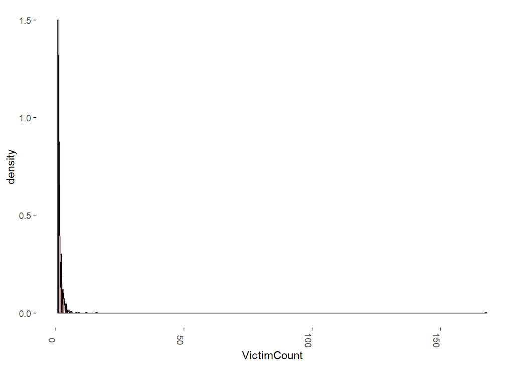

```r
ggplot(DeathP, aes(x=VictimCount)) +
    geom_histogram(aes(y=..density..),
                   binwidth=.5,
                   colour="black", fill="white") +
    geom_density(alpha=.2, fill="#FF6666")
```

This plot does not tell the full story, this is because of an outlier in the dataset, We will try this data again without the outlier.

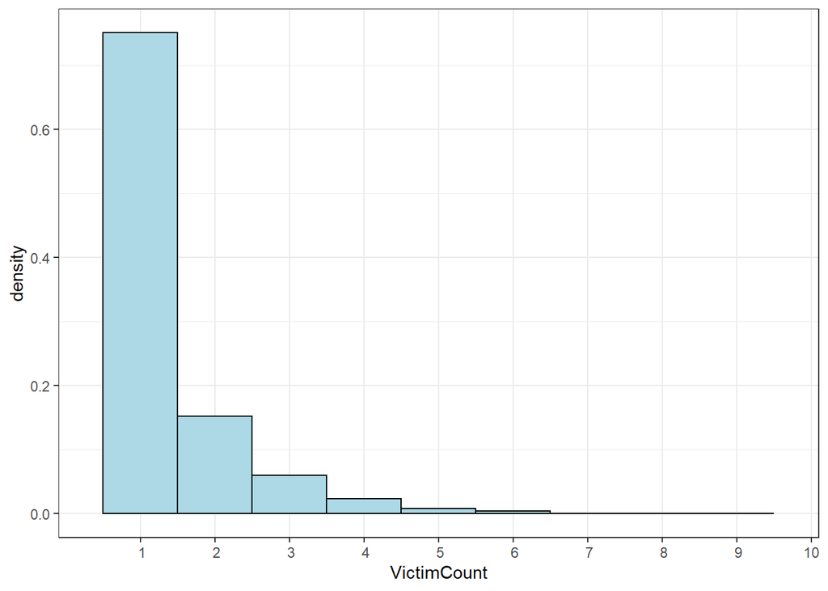

```r
noout<- DeathP %>%
  filter(Name != 'Timothy McVeigh*',Name != 'Ronald Simmons',Name != 'John Gacy')

ggplot(noout, aes(x=VictimCount))+
  geom_histogram(aes(y=..density..),
                   binwidth=1,
                   colour="black", fill= "lightblue")+
  theme_bw()+
  scale_x_discrete(limits=c(1,2,3,4,5,6,7,8,9,10))
```

In addition we can observe discrete Probability Distributions again without the outliers as to not skew the data too hard, therefore we will be focusing on individuals with 10 or fewer Victim Counts.

```r
Death1 <- length(which(DeathP$VictimCount == 1))
Death2 <- length(which(DeathP$VictimCount == 2))
Death3 <- length(which(DeathP$VictimCount == 3))
Death4 <- length(which(DeathP$VictimCount == 4))
Death5 <- length(which(DeathP$VictimCount == 5))
Death6 <- length(which(DeathP$VictimCount == 6))
Death7 <- length(which(DeathP$VictimCount == 7))
Death8 <- length(which(DeathP$VictimCount == 8))
Death9 <- length(which(DeathP$VictimCount == 9))
Death10 <- length(which(DeathP$VictimCount == 10))



numberofvictims<- c(1,2,3,4,5,6,7,8,9,10)
probability0 <- c(1081/1439,169/1439,86/1439,34/1439,11/1439,6/1439,0/1439,1/1439,1/1439,0/1439)

probability<- formatC( round(probability0, 3), format='f', digits=3 )
bind <- cbind(numberofvictims,probability)
bind2 <- data.frame(bind)


formattable(bind2,
            align = c("c","c" ),
            list('probability' = formatter(
              "span" , style = ~style(color = "gray", font.weight = "bold" )),
              'probability' = color_tile("white", "lightblue")))
```

[output not shown]

We can also look at the different statistical analysis of the data without the outliers. (1-10).

```r
#This is the values for the ones without outliers,
noout<- DeathP %>%
  filter(Name != 'Timothy McVeigh*',Name != 'Ronald Simmons',Name != 'John Gacy')

Analysis<- c("min","Max","Median","S.D.","Variance", "Mean", "Expected Value")
V1 <- c(1.00,9.00,1.00, 0.857, 0.734, 1.40, 1.335)

Values<- formatC( round(V1, 3), format='f', digits=3)
bind3 <- cbind(Analysis,Values)
bind4 <- data.frame(bind3)

Values<- formatC( round(V1, 3), format='f', digits=3)
bind3 <- cbind(Analysis,Values)
bind4 <- data.frame(bind3)


formattable(bind4,
            align = c("l","l" ),
            list('probability' = formatter(
             style = ~style(color = "gray", font.weight = "bold" )),
              'probability' = color_tile("white", "lightblue")))
```

| Analysis | Values |
| --- | --- |
| min | 1.000 |
| Max | 9.000 |
| Median | 1.000 |
| S.D. | 0.857 |
| Variance | 0.734 |
| Mean | 1.400 |
| Expected Value | 1.335 |

**9) Referring to all the probabilities you’ve computed above: are these theoretical probabilities or relative frequency probabilities? How does that contextualize the conclusions you’ve made? What does the Law of Large Numbers have to say about it all?**

- The relative frequency of an event is defined as the number of times that the event occurs during experimental trials, divided by the total number of trials conducted
- Theoretical probability is the total number of times a given result came up in an experiment or study; the total number of times an event occurs. It can be said that frequency simply means the rate of occurrence.
- During our probability calculations, we analysed the relative frequency of our data. This helps determine the frequency of events related to the total number of times a event has occured.
- In probability theory, the law of large numbers is a theorem that describes the result of performing the same experiment a large number of times. According to the law, the average of the results obtained from a large number of trials should be close to the expected value, and will tend to become closer as more trials are performed.
  - This means that since our data has a large number of individuals, and we are finding the relative frequency, the predicted values should be close to the expected value.

# Extra Analysis:

I thought that the probability analysis was interesting, but I wanted to do some extra analysis as I found the data interesting and I wanted to use the skills I have learned and apply them to this dataset.

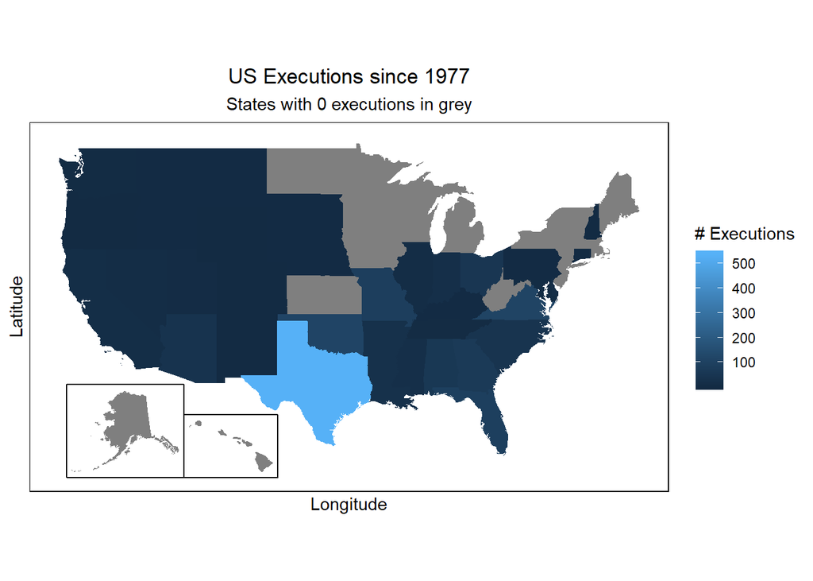

```r
DeathEx <- read_excel('DeathEx.xlsx')
data("fifty_states")

ggplot(DeathEx, aes(map_id = state)) +
  geom_map(aes(fill = Death), map = fifty_states) +
  expand_limits(x = fifty_states$long, y = fifty_states$lat) +
  coord_map() +
  scale_x_continuous(breaks = NULL) +
  scale_y_continuous(breaks = NULL) +
  scale_fill_gradient()+
  labs(x = "Longitude", y = "Latitude", title='US Executions since 1977',
       subtitle = "States with 0 executions in grey", fill='# Executions')+
  theme(legend.position = "right",
        panel.background = element_blank())+
  theme(panel.background = element_rect(fill = NA)) +
  theme(plot.subtitle = element_text(hjust = 0.5,
    vjust = 1), plot.caption = element_text(vjust = 0),
    plot.title = element_text(hjust = 0.5))+
  fifty_states_inset_boxes()
```

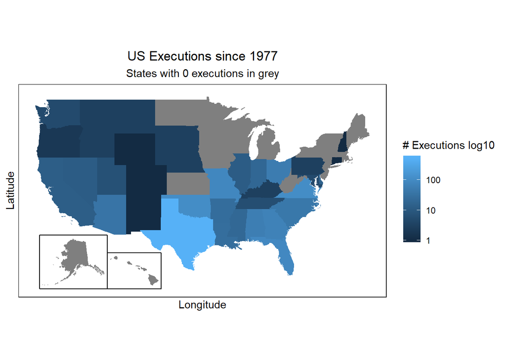

```r
ggplot(DeathEx, aes(map_id = state)) +
  geom_map(aes(fill = Death), map = fifty_states) +
  expand_limits(x = fifty_states$long, y = fifty_states$lat) +
  coord_map() +
  scale_x_continuous(breaks = NULL) +
  scale_y_continuous(breaks = NULL) +
  scale_fill_gradient(trans = "log10")+
  labs(x = "Longitude", y = "Latitude", title='US Executions since 1977',
       subtitle = "States with 0 executions in grey", fill='# Executions log10')+
  theme(legend.position = "right",
        panel.background = element_blank())+
  theme(panel.background = element_rect(fill = NA)) +
  theme(plot.subtitle = element_text(hjust = 0.5,
    vjust = 1), plot.caption = element_text(vjust = 0),
    plot.title = element_text(hjust = 0.5))+
  fifty_states_inset_boxes()
```

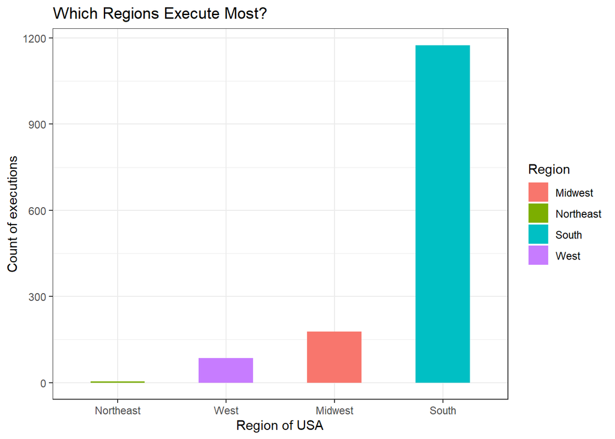

```r
DeathP %>%
  count(Region)%>%
  ggplot(aes(reorder(Region, n),n, fill=Region))+
  geom_col(position = 'dodge', width = .5)+
  theme_bw()+
  labs(y='Count of executions', x='Region of USA', title='Which Regions Execute Most?')
```

Here we are able to see something similar to the map only in a more categorical representatio We are able to see that the south has an extrordinary amount of death penalties. Of course this is with the inclution of texas which has more death penalties than any other state. This still shows that the south is the dominant region when it comes to death penalties in the United states. Likewise we are able to see that the Northeast region of the united states has very few compared to even the midwest or western United States.

To continue this small exploration, I wanted to look at the top 5 states primarly as they have the most amount of data. I thought it would be interesting to look at the distribution of excecuted age as well as the racial breakdown between states.

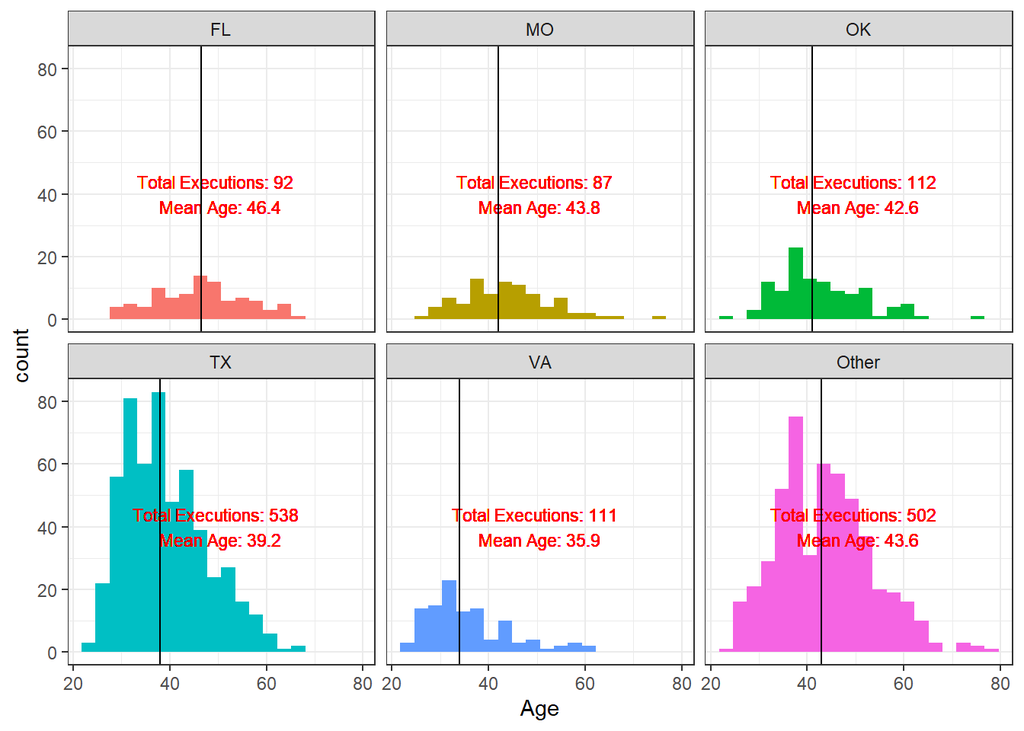

```r
DeathP %>%
  mutate(new_state = fct_lump(State, n=5))%>%
  group_by(new_state)%>%
  mutate(new_state_ct = n(),
         avg_age = round(mean(Age),1),
         med_age = round(median(Age),1))%>%
  ggplot(aes(Age, fill=new_state))+
  geom_histogram(bins=20)+
  geom_text(aes(x = 50, y= 40,label = paste("Total Executions:",new_state_ct,'\n','Mean Age:',avg_age)), color='red', size=3)+
  geom_vline(aes(xintercept = med_age))+
  facet_wrap(~ new_state)+
  guides(fill=FALSE)+
  theme_bw()
```

We will look at the top 5 states, Florida, Texas, Virgina, Missouri, Oklahoma as well as the rest of the states displayed as “Other”. Here we are able to see that Texas has the largest amount of younger inmates being excecuted. Although virgina has the lowest age by 4 years, they only have about a fifth of the total nuymber of excecutions. Florida on the other hand has the oldest mean age of excecution. This could be due to the older average age of florida or due to regulations in their system on how long it takes for inmates to be executed in different states. Although I can not be certain of the reason for excecution, It is interesting to see the relationship to age and difference between states.

Furthermore, I wanted to look at the age difference between men and Women on death road.

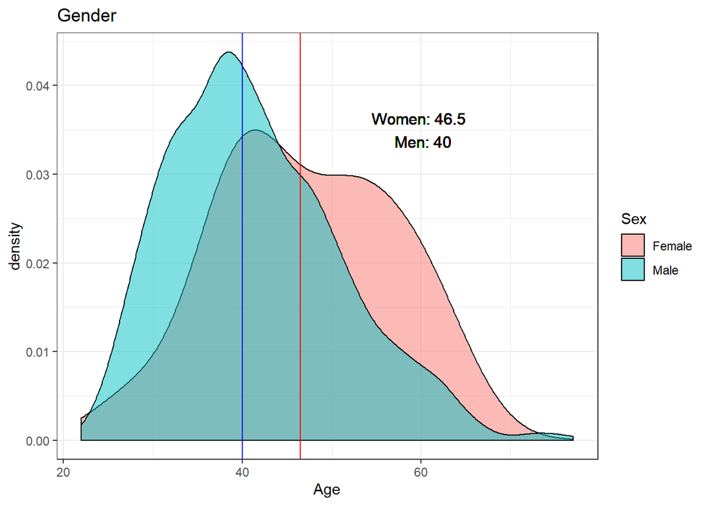

```r
med_age <- DeathP %>%
  group_by(Sex)%>%
  summarise(cts = n(),
            med_age = median(Age, na.rm=TRUE))

plot_gender <- DeathP %>%
  group_by(Sex)%>%
  ggplot(aes(Age, fill=Sex))+
  geom_density(alpha=.5)

plot_gender +
  geom_vline(xintercept = med_age$med_age[1], data=med_age, color='red')+
  geom_vline(xintercept = med_age$med_age[2], data=med_age, color='blue')+
  theme_bw()+
  labs(title='Gender')+
  geom_text(aes(x = 60, y= 0.035,label = paste("Women: 46.5", "\n", "Men: 40")), color='black', size=4)
```

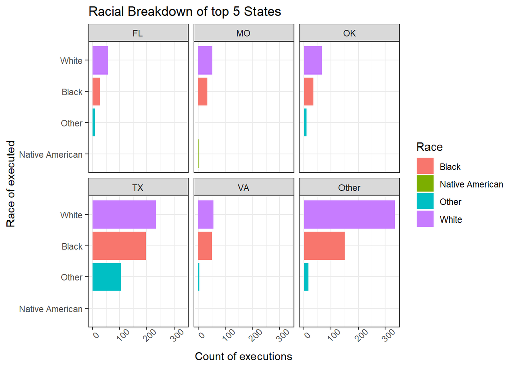

```r
DeathP %>%
  mutate(new_state = fct_lump(State, n=5))%>%
  group_by(new_state)%>%
  mutate(Race = fct_lump(Race, n=2))%>%
  count(Race)%>%
  ggplot(aes(reorder(Race,n),n, fill=Race))+
  geom_col()+
  coord_flip()+
  facet_wrap(~ new_state)+
  theme_bw() +
  theme(axis.text.x = element_text(angle = 45))+
  labs(y='Count of executions', x='Race of executed', title='Racial Breakdown of top 5 States')
```

Since a lot of our probability analysis was regarding race of Excecuted individuals, I though that it would be interesting again to look at the top 5 states, Florida, Texas, Virgina, Missouri, Oklahoma as well as the rest of the states displayed as “Other”, in regards of race. We see that the greatest racial category in each state as well as every other state is primarely White, With the majority of “Other” in Texas. I find this very intersting as there is a ongoing problem with race in the prison system in america which is not displayed here in this data. This could be as it has been a recent evolvmenet or other unknown variables .

# Conclusion